# Vector analysis with Matlab

Interactive Matlab scripts for teaching vector analysis, with worked examples such as Stokes' theorem that students can modify and explore in 3D.

When teaching [Vector Analysis](https://applicationspub.unil.ch/interpub/noauth/php/Ud/ficheCours.php?v_enstyid=85180&v_ueid=258&v_etapeid1=21798&v_langue=en&v_isinterne=) and fluid mechanics, I’ve found it useful to create Matlab scripts where students can interactively code and play around with examples in 3D.

Download the code

Here’s an example for demonstrating Stoke’s theorem:

# Stokes Theorem

Stokes theorem says that:

\[\int \int_S \left(\nabla \times F\right)\cdot {\mathrm{d}}S=\oint_{\partial S} F\cdot {\mathrm{d}}\left({\partial S}\right)\]

Where \(S\) is an open surface in 3D space with boundary curve \(\partial \;S\) , \(\mathit{\mathbf{F}}\) is a vector field with curl \(\nabla \times F\) , \(\textrm{dS}\) is an area element normal to the surface, and \(\partial \;\mathit{\mathbf{S}}\) is a tangent vector to the boundary.

This really means:

\[\int_v \int_u \left(\nabla \times F\right)\cdot n{\mathrm{d}}u{\mathrm{d}}v=\oint_t F\cdot t{\mathrm{d}}t\]

where \(n\) is the normal to the surface, \(t\) is the tangent to the bounary curve, and \(u\) , \(v\) and \(t\) parametrise the surface and boundary curve respectively.

For example, let’s say we have a vector field:

\[F=\left(y,0,0\right)\]

This can be visualised as:

```matlab
Fx = @(x,y,z) y;
Fy = @(x,y,z) zeros(size(y));
Fz = @(x,y,z) zeros(size(z));

x = linspace(-1,1,6);
y = linspace(-1,1,6);
z = linspace(-1,1,6);

[X, Y, Z] = meshgrid(x, y, z);

figure();
hold on
xlabel(' $$x$$ ')
ylabel(' $$y$$ ')
zlabel(' $$z$$ ')
axis square
quiver3(X, Y, Z, Fx(X,Y,Z), Fy(X, Y, Z), Fz(X,Y,Z), 'b')
```

The curl of a vector field describes how much it would cause an object at that exact point to rotate. It results in a vector field, given in cartesian coordinates by:

\[\nabla \times F=\left(\frac{\partial F_z }{\partial y}-\frac{\partial F_y }{\partial z},\frac{\partial F_x }{\partial z}-\frac{\partial F_z }{\partial x},\frac{\partial F_y }{\partial x}-\frac{\partial F_x }{\partial y}\right)\]

Let’s plot that for our current vector field:

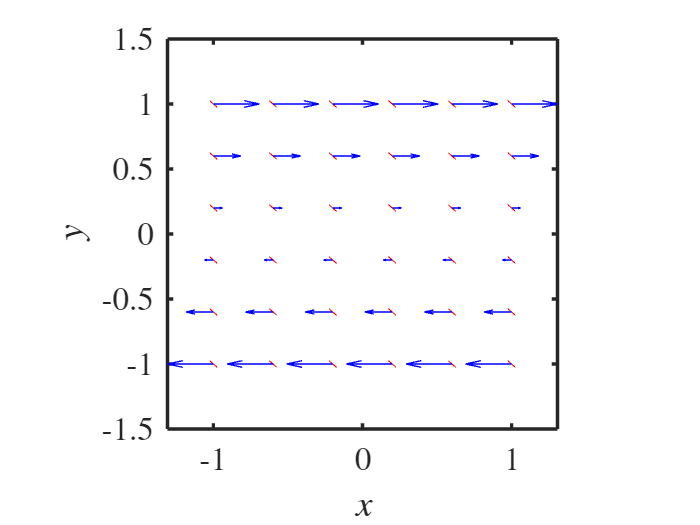

```matlab
cFx = @(x,y,z) zeros(size(y));
cFy = @(x,y,z) zeros(size(y));
cFz = @(x,y,z) -ones(size(y));
quiver3(X, Y, Z, cFx(X,Y,Z), cFy(X,Y,Z), cFz(X,Y,Z), 'r')
```

Think about putting a little needle in the flow. Which way would it rotate? The curl points in a direction perpendicular to the ‘plane’ of rotation, and its magnitude is half the angular velocity. Convince yourself that this is right for our current vector field.

Now let’s see if we can apply Stokes theorem to this vector field. Let’s take a parametric surface of a disk:

```matlab
u0 = 0;
u1 = 1;
v0 = 0;
v1 = 1;

% disk
x = @(u,v) cos(u*2*pi).*v;
y = @(u,v) sin(u*2*pi).*v;
z = @(u,v) zeros(size(u));

% plot our surface
surfacesViewer(u0, u1, v0, v1, x, y, z);
```

This surface is a disk in the \(z=0\) plane, where the \(u\) parameter describes the angle around the circle. \(S\) is the surface of the disk, the boundary curve (the parametric curve with \(v=1\) fixed in this case, a good exercise is to convince yourself that this is indeed a parametric curve) is \(\partial \;S\) .

We now plot the vector field and the curl.

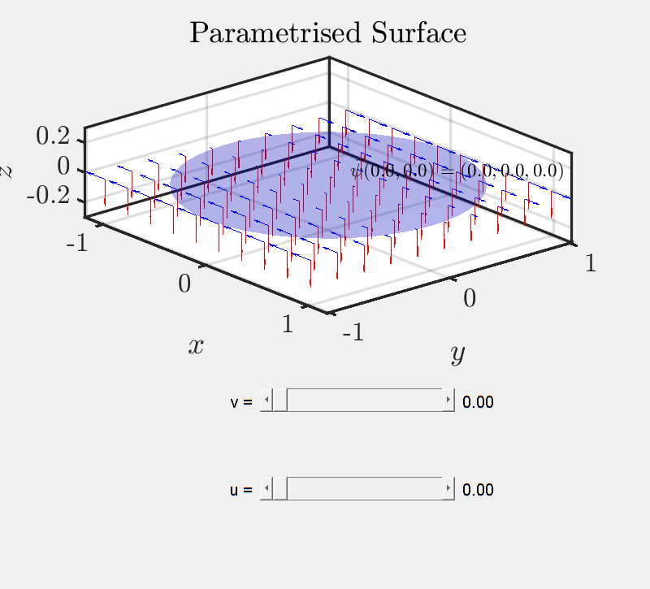

```matlab
% plot our vector fields
x = linspace(-1,1,10);
y = linspace(-1,1,10);
z = zeros(size(x));

[X, Y, Z] = meshgrid(x, y, z);
hold on
axis equal
zlim([-0.3, 0.3])
quiver3(X, Y, Z, Fx(X,Y,Z), Fy(X, Y, Z), Fz(X,Y,Z), 'b')
quiver3(X, Y, Z, cFx(X,Y,Z), cFy(X,Y,Z), cFz(X,Y,Z), 'r')
```

This is how one should visualise Stokes theorem: the amount of red arrows going through the disk is equal to adding all the blue arrows around the boundary of the disk. The amount going through the disk is the *flux of the curl* of the vector field \(F\) , and the integral around the boundary is the *circulation* of \(F\) around the boundary.

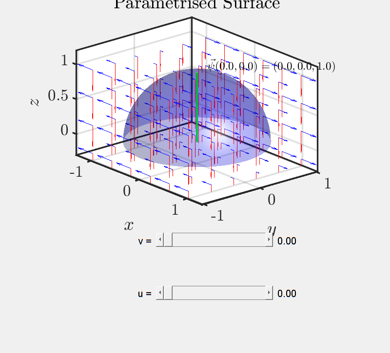

```matlab
% sphere
x = @(u,v) sin(v*pi/2).*cos(u*2*pi);
y = @(u,v) sin(v*pi/2).*sin(u*2*pi);
z = @(u,v) cos(v*pi/2);

surfacesViewer(u0, u1, v0, v1, x, y, z);

x = linspace(-1,1,6);
y = linspace(-1,1,6);
z = linspace(-1,1,6);

[X, Y, Z] = meshgrid(x, y, z);
hold on
axis equal
zlim([-0.3, 1.2])
quiver3(X, Y, Z, Fx(X,Y,Z), Fy(X, Y, Z), Fz(X,Y,Z), 'b')
quiver3(X, Y, Z, cFx(X,Y,Z), cFy(X,Y,Z), cFz(X,Y,Z), 'r')
```

For this simple case, one should convince themselves visually that the flux should be the same through both surfaces! When doing it mathematically, you’ll likely find some surfaces are far easier than others, which can be a very useful calculation tool.

```matlab
% Developed by Isaac Pincus, 2025 (with some help from Claude to create the dyanmic sliders)
```